# Keras, R 다중 선형회귀

오준서(조장), 이순규, 한호종, 유준

2022 - 02 - 14

이번 포트폴리오에서는 Keras패키지를 사용하여 다중선형회귀를 하고, R 내장 회귀함수와 결과를 비교하고자 한다.

# 보스턴 주택 가격 데이터셋

```r
train_df
```

```
## # A tibble: 354 x 14
##       CRIM    ZN INDUS  CHAS   NOX    RM   AGE   DIS   RAD   TAX PTRATIO      B
##      <dbl> <dbl> <dbl> <dbl> <dbl> <dbl> <dbl> <dbl> <dbl> <dbl>   <dbl>  <dbl>
##  1  0.0195  17.5  1.38     0 0.416  7.10  59.5  9.22     3   216    18.6 393.
##  2  0.149    0    8.56     0 0.52   6.73  79.9  2.78     5   384    20.9 395.
##  3 25.0      0   18.1      0 0.693  5.99 100    1.59    24   666    20.2 397.
##  4  3.67     0   18.1      0 0.583  6.31  51.9  3.99    24   666    20.2 389.
##  5  9.51     0   18.1      0 0.713  6.73  94.1  2.50    24   666    20.2   6.68
##  6  0.0459  52.5  5.32     0 0.405  6.32  45.6  7.32     6   293    16.6 397.
##  7  0.123    0   10.0      0 0.547  5.91  92.9  2.35     6   432    17.8 395.
##  8 10.2      0   18.1      0 0.614  6.18  96.7  2.17    24   666    20.2 380.
##  9  0.0438  80    3.37     0 0.398  5.79  31.1  6.61     4   337    16.1 397.
## 10  0.0788  45    3.44     0 0.437  6.78  41.1  3.79     5   398    15.2 394.
## # ... with 344 more rows, and 2 more variables: LSTAT <dbl>, label <dbl>
```

```r
test_df
```

```
## # A tibble: 152 x 14
##       CRIM    ZN INDUS  CHAS   NOX    RM   AGE   DIS   RAD   TAX PTRATIO     B
##      <dbl> <dbl> <dbl> <dbl> <dbl> <dbl> <dbl> <dbl> <dbl> <dbl>   <dbl> <dbl>
##  1  0.0273     0  7.07     0 0.469  7.18  61.1  4.97     2   242    17.8  393.
##  2  1.21       0 19.6      0 0.605  5.88  94.6  2.43     5   403    14.7  292.
##  3  1.46       0 19.6      0 0.605  7.49  90.8  1.97     5   403    14.7  374.
##  4  0.0566     0  3.41     0 0.489  7.01  86.3  3.42     2   270    17.8  397.
##  5  0.0362    80  4.95     0 0.411  6.63  23.4  5.12     4   245    19.2  397.
##  6  0.269      0  9.9      0 0.544  6.27  82.8  3.26     4   304    18.4  393.
##  7  0.188      0  6.91     0 0.448  5.79  33.3  5.10     3   233    17.9  397.
##  8 11.1        0 18.1      0 0.718  6.41 100    1.86    24   666    20.2  319.
##  9  0.0839     0 12.8      0 0.437  5.87  36.6  4.50     5   398    18.7  396.
## 10  0.103     30  4.93     0 0.428  6.36  52.9  7.04     6   300    16.6  373.
## # ... with 142 more rows, and 2 more variables: LSTAT <dbl>, label <dbl>
```

### 보스턴 시의 주택 가격에 대한 데이터

보스턴 시의 주택 가격에 대한 데이터이다.

주택의 여러가진 요건들과 주택의 가격 정보가 포함되어 있다.

주택의 가격에 영향을 미치는 요소를 분석하고자 하는 목적으로 사용될 수 있다.

1. CRIM - 도시별 1인당 범죄율
2. ZN - 25,000평방피트 이상의 부지로 구획된 주거용 토지의 비율.
3. INDUS - 도시당 비소매업 에이커 비율.
4. CHAS - Charles River 더미 변수(트랙 경계가 강인 경우 1, 그렇지 않은 경우 0)
5. NOX - 산화질소 농도(1000만분의 1)
6. RM - 주택당 평균 방 수
7. AGE - 1940년 이전에 지어진 소유주가 차지하는 비율
8. DIS - 5개의 보스턴 고용 센터까지의 가중 거리
9. RAD - 방사형 고속도로에 대한 접근성 지수
10. TAX - $10,000당 전체 가치 재산세율
11. PTRATIO - 도시별 학생-교사 비율
12. B - 1000(Bk - 0.63)^2 여기서 Bk는 도시별 흑인 비율입니다.
13. LSTAT - 인구의 낮은 상태 %
14. label - $1000의 소유자가 거주하는 주택의 중간 가치

### 분석목표

주어진 데이터 셋을 활용하여 미국 보스톤 지역의 집값을 예측한다.

# Python - keras패키지 다중 회귀 함수

### 데이터 생성

```python
(train_data, train_targets), (test_data, test_targets) = boston_housing.load_data()

column_names = ['CRIM', 'ZN', 'INDUS', 'CHAS', 'NOX', 'RM', 'AGE', 'DIS', 'RAD', 'TAX', 'PTRATIO', 'B', 'LSTAT']
df = pd.DataFrame(train_data, columns=column_names)
df.head()
```

```
##       CRIM    ZN  INDUS  CHAS    NOX  ...   RAD    TAX  PTRATIO       B  LSTAT
## 0  1.23247   0.0   8.14   0.0  0.538  ...   4.0  307.0     21.0  396.90  18.72
## 1  0.02177  82.5   2.03   0.0  0.415  ...   2.0  348.0     14.7  395.38   3.11
## 2  4.89822   0.0  18.10   0.0  0.631  ...  24.0  666.0     20.2  375.52   3.26
## 3  0.03961   0.0   5.19   0.0  0.515  ...   5.0  224.0     20.2  396.90   8.01
## 4  3.69311   0.0  18.10   0.0  0.713  ...  24.0  666.0     20.2  391.43  14.65
##
## [5 rows x 13 columns]
```

### 표준화

```python
df1 = df.loc[:,df.columns !='CHAS']
train_data = np.array(df1)


df2 = pd.DataFrame(test_data, columns=column_names)
df2 = df2.loc[:,df2.columns !='CHAS']
test_data = np.array(df2)

mean = train_data.mean(axis=0)
train_data -= mean
std = train_data.std(axis=0)
train_data /= std

test_data -= mean
test_data /= std
```

서로 다른 범위를 갖고 있다면, 직접적인 비교가 어렵기 때문에 이를 동일한 범위를 갖도록 해주는 작업이다.

테스트 데이터를 정규화할 때 사용한 값이 훈련 데이터에서 계산한 값임을 주목해야만 한다.

머신 러닝 작업 과정에서 절대로 테스트 데이터에서 계산한 어떤 값도 사용해서는 안 된다.

각각 다른 스케일로 변환하게 되면 훈련데이터에서 학습한 정보가 쓸모없게 되는 것이다.

### 훈련, 검증 데이터 순서 섞기

```python
order = np.argsort(np.random.random(train_targets.shape))
train_targets = train_targets[order]
train_data = train_data[order]
```

학습을 할 때, 비슷한 데이터들을 연속해서 학습하게 되면 편향이 된다.

따라서, 학습 데이터들을 적절하게 섞어주는 것이 필요하다.

### 모델생성

```python
model = Sequential()
model.add(Dense(64, activation='relu', input_shape=(train_data.shape[1],)))
model.add(Dense(64, activation='relu'))
model.add(Dense(1))
```

입력 레이어, 히든 레이어, 출력 레이어 각 1개씩 전결합 (Fully-Connected) 레이어로 만들었다.

활성화 함수로는 `ReLU`를 사용했다.

### 컴파일링

```python
model.compile(loss='mse', optimizer=Adam(lr=0.001), metrics=['mae'])
```

손실 함수로는 MSE (Mean Square Error)를 사용했고,

최적화 함수로는 학습률 0.001의 Adam을 사용했다.

평가 지표로는 MAE (Mean Absolute Error)를 사용했다.

### 모델 훈련

```python
early_stop = EarlyStopping(monitor='val_loss', patience=20)
history = model.fit(train_data, train_targets, epochs=500, validation_split=0.2, callbacks=[early_stop])
```

`EarlyStopping`은 지정한 epoch만큼 반복하는 동안 학습 오차에 개선이 없다면 자동으로 학습을 종료한다.

val_loss를 모니터링하여 20번의 epoch동안 개선이 없다면 종료하게 된다.

모델을 훈련시킬때 `EarlyStopping`에서 반환된 값을 넘겨주어 학습을 하는 동안 사용 하게 된다.

epochs는 전체 데이터 셋에 대해 한 번 학습을 완료한 상태로, 딥러닝의 반복학습의 횟수라 볼 수 있다.

validation_split는 트레이닝 데이터셋과 테스트 데이터셋의 비율을 결정한다.

즉, 여기서는 0.2의 의미는 0.8의 트레이닝 셋, 0.2의 검증셋을 말한다.

verbose는 Verbosity mode로 학습의 진행상황 옵션이다.

### 훈련 결과 시각화

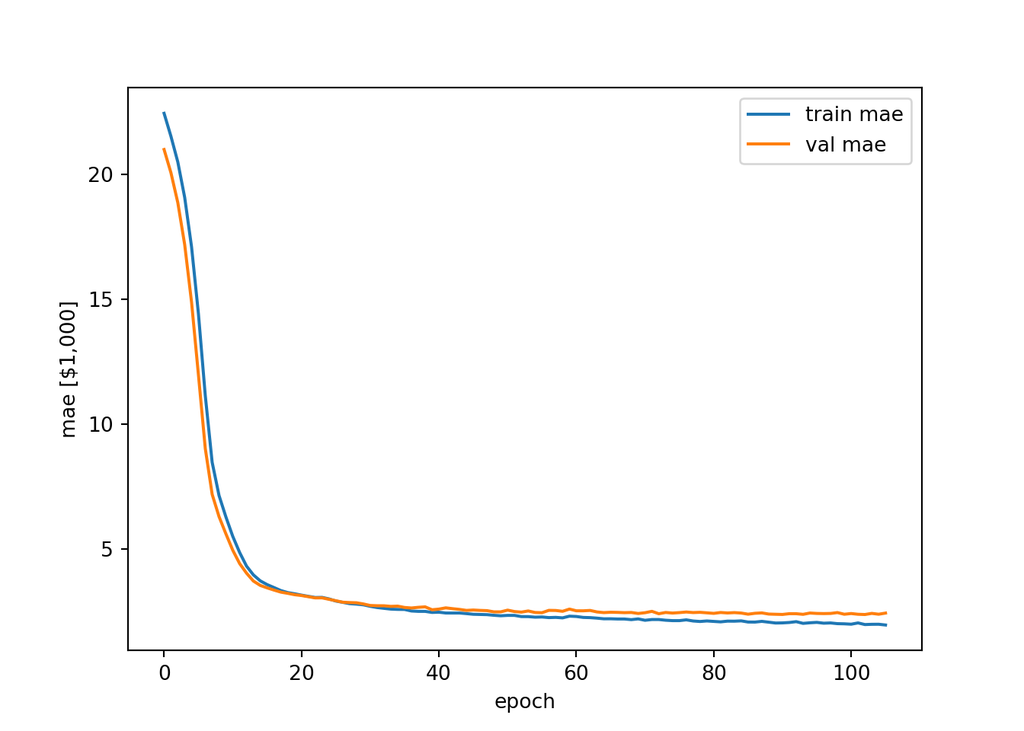

```python
plt.plot(history.history['mae'], label='train mae')
plt.plot(history.history['val_mae'], label='val mae')
plt.xlabel('epoch')
plt.ylabel('mae [$1,000]')
plt.legend(loc='best')
```

106번째 이후로는 개선사항이 발견되지 않아 학습이 멈추었다는 것을 알 수 있다.

### 모델 평가

```python
test_mae
```

```
## MAE : 2.8617
```

mae(평균절대오차)가 2.8617 이므로 평균적으로

약 2,862 달러 정도의 오차 범위 내에서 예측하고 있다.

### 모델 예측, 비교 시각화

```python
test_predictions = model.predict(test_data).flatten()
plt.scatter(test_targets, test_predictions)
plt.xlabel('test_targets')
plt.ylabel('test_predictions')
plt.axis('equal')
```

```python
plt.axis('square')
```

```python
plt.xlim([0,plt.xlim()[1]])
```

```python
plt.ylim([0,plt.ylim()[1]])
```

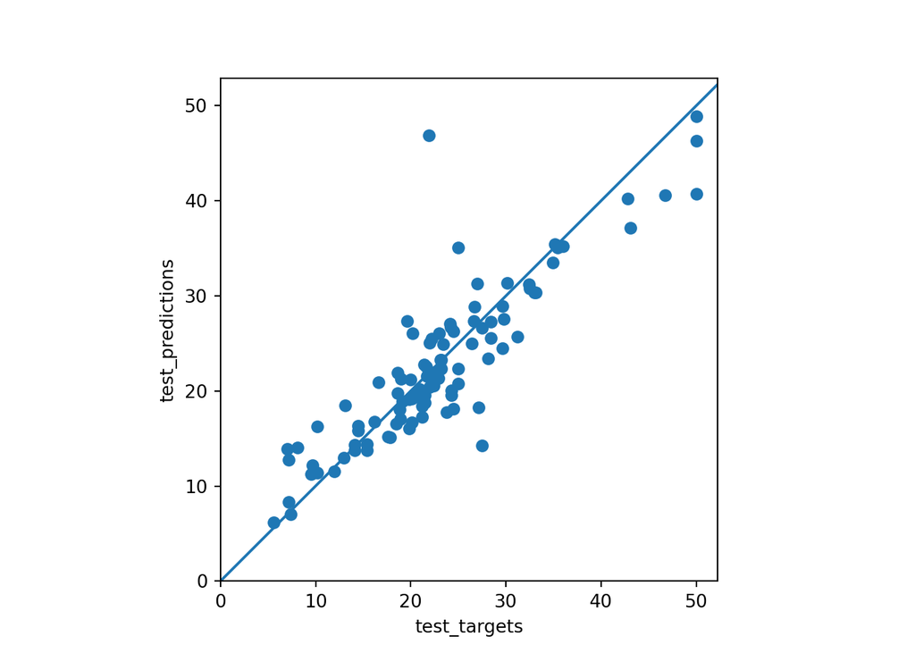

```python
_ = plt.plot([-100, 100], [-100, 100])
```

예측값과 실제값의 비교 그래프이다.

대부분 예측이 잘 되었고, 한개의 이상치가 존재한다.

# R - keras패키지 다중 회귀 함수

### 표준화

```r
spec <- feature_spec(train_df, label ~ . ) %>%
  step_numeric_column(all_numeric(), normalizer_fn = scaler_standard()) %>%
  fit()

spec
```

```
## -- Feature Spec ----------------------------------------------------------------
## A feature_spec with 13 steps.
## Fitted: TRUE
## -- Steps -----------------------------------------------------------------------
## The feature_spec has 1 dense features.
## StepNumericColumn: CRIM, ZN, INDUS, CHAS, NOX, RM, AGE, DIS, RAD, TAX, PTRATIO, B, LSTAT
## -- Dense features --------------------------------------------------------------
```

spec 변수에 `feature_spec()` 함수를 사용하여 기능 사양(feature specification)을 지정한다.

scaler_standard는 평균 및 표준편차를 표준화하고, scaler_min_max는 최소 최대 정규화 할 수 있다.

### 모델생성

```r
input <- layer_input_from_dataset(train_df %>% select(-label))

output <- input %>%
  layer_dense_features(dense_features(spec)) %>%
  layer_dense(units = 64, activation = "relu") %>%
  layer_dense(units = 64, activation = "relu") %>%
  layer_dense(units = 1)

model <- keras_model(input, output)
summary(model)
```

```
## Model: "model"
## ________________________________________________________________________________
##  Layer (type)             Output Shape      Param #  Connected to
## ================================================================================
##  AGE (InputLayer)         [(None,)]         0        []
##
##  B (InputLayer)           [(None,)]         0        []
##
##  CHAS (InputLayer)        [(None,)]         0        []
##
##  CRIM (InputLayer)        [(None,)]         0        []
##
##  DIS (InputLayer)         [(None,)]         0        []
##
##  INDUS (InputLayer)       [(None,)]         0        []
##
##  LSTAT (InputLayer)       [(None,)]         0        []
##
##  NOX (InputLayer)         [(None,)]         0        []
##
##  PTRATIO (InputLayer)     [(None,)]         0        []
##
##  RAD (InputLayer)         [(None,)]         0        []
##
##  RM (InputLayer)          [(None,)]         0        []
##
##  TAX (InputLayer)         [(None,)]         0        []
##
##  ZN (InputLayer)          [(None,)]         0        []
##
##  dense_features (DenseFea  (None, 13)       0        ['AGE[0][0]',
##  tures)                                               'B[0][0]',
##                                                       'CHAS[0][0]',
##                                                       'CRIM[0][0]',
##                                                       'DIS[0][0]',
##                                                       'INDUS[0][0]',
##                                                       'LSTAT[0][0]',
##                                                       'NOX[0][0]',
##                                                       'PTRATIO[0][0]',
##                                                       'RAD[0][0]',
##                                                       'RM[0][0]',
##                                                       'TAX[0][0]',
##                                                       'ZN[0][0]']
##
##  dense_5 (Dense)          (None, 64)        896      ['dense_features[0][0]']
##
##  dense_4 (Dense)          (None, 64)        4160     ['dense_5[0][0]']
##
##  dense_3 (Dense)          (None, 1)         65       ['dense_4[0][0]']
##
## ================================================================================
## Total params: 5,121
## Trainable params: 5,121
## Non-trainable params: 0
## ________________________________________________________________________________
```

keras 패키지의 `layer_dense()` 함수를 통해 연산을 실행한다.

units는 뉴런의 개수, activation은 활성화 함수로, relu는 정류된 선형 단위 활성화 함수를 적용한다.

relu 외에도, sigmoid, softmax, tanh 등등이 있다.

### 컴파일링

```r
model <-  model %>%
  compile(
    loss = "mse",
    optimizer = optimizer_adam(learning_rate = 0.001),
    metrics = list("mean_absolute_error")
  )
```

loss는 손실함수, optimizer는 최적화, metrics는 측정항목을 말한다.

### 모델 훈련

```r
early_stop <- callback_early_stopping(monitor = "val_loss", patience = 20)

history <- model %>% fit(
  x = train_df %>% select(-label),
  y = train_df$label,
  epochs = 500,
  validation_split = 0.2,
  verbose = 0,
  callbacks = list(early_stop)
)
```

파이썬의 모델훈련 옵션고 설명이 같다.

0 = silent 숨김, 1 = progress bar 보임, 2 = one line per epoch 한줄로 표시 옵션이다.

### 시각화

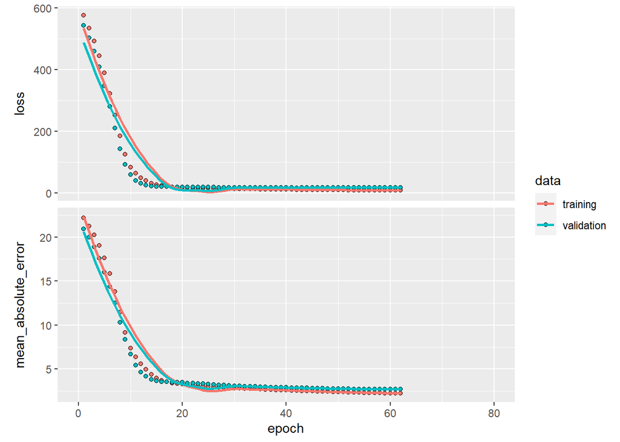

```r
plot(history) +
   scale_x_continuous(limits = c(0, 80))
```

epoch = 20 이후로 loss = MSE 와 MAE가 매우 작아지는 것을 볼 수 있다.

### 모델 예측, 비교 시각화

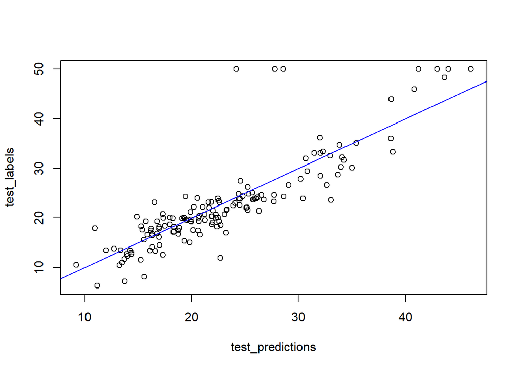

```r
test_predictions <- model %>% predict(test_df %>% select(-label))
plot(test_predictions, test_labels)
abline(a=0,b=1,col="blue",lty=1)
```

몇몇 이상치가 존재하지만, 대부분 예측을 함에 있어 좋은 결과를 보이고 있다.

### 모델 평가

```r
c(loss, mae) %<-% (model %>% evaluate(test_df %>% select(-label), test_df$label, verbose = 0))
```

```r
paste0("MAE: $", sprintf("%.2f", mae * 1000))
```

```
## [1] "MAE: $2900.79"
```

2900달러의 오차 수준으로 예측하고 있다.

# R - 내장 다중 회귀 함수

### 표준화

모두 같은 기준으로 데이터를 분석하고 해석하기 위하여 데이터의 범위가 같아지도록 표준화를 진행한다.

`scale`함수를 이용하여 표준화를 하는데, `scale`함수는 *X-Mean(x)/Sd(x)*의 식을 사용하여 표준화 한다.

표준화를 하기 전, 범주형 컬럼과 예측하려는 컬럼을 제거하고 표준화를 진행한다.

```r
train_scale <- train_df[, c(-4,-14)] %>% scale() %>% cbind(label) %>% data.frame()
head(train_scale)
```

```
##          CRIM         ZN      INDUS        NOX           RM        AGE
## 1 -0.44700444  0.2489311 -1.4268634 -1.2263027  1.100330484 -0.3415003
## 2 -0.43229213 -0.4965986 -0.3866429 -0.3174121  0.581273722  0.3829088
## 3  2.40393636 -0.4965986  0.9954885  1.1959475 -0.437564485  1.0966648
## 4 -0.03073543 -0.4965986  0.9954885  0.2336957  0.009898241 -0.6113781
## 5  0.63453220 -0.4965986  0.9954885  1.3709024  0.582650530  0.8871543
## 6 -0.44399818  1.7399906 -0.8560460 -1.3234026  0.014028666 -0.8350927
##          DIS        RAD        TAX     PTRATIO          B      LSTAT label
## 1  2.5618411 -0.7690291 -1.1514198  0.06144064  0.4125989 -0.6669983  33.0
## 2 -0.4631435 -0.5418816 -0.1663059  1.12354185  0.4284410 -0.4801275  27.5
## 3 -1.0211964  1.6160198  1.4872782  0.80029365  0.4507451  1.8864479   5.6
## 4  0.1065961  1.6160198  1.4872782  0.80029365  0.3644471 -0.3219011  21.2
## 5 -0.5953584  1.6160198  1.4872782  0.80029365 -3.6163063  0.7870475  14.9
## 6  1.6674076 -0.4283078 -0.6999093 -0.86212563  0.4507451 -0.7283792  22.3
```

```r
test_scale <- test_df[, c(-4,-14)] %>% scale() %>%  cbind(label2) %>%  data.frame()
head(test_scale)
```

```
##         CRIM         ZN      INDUS         NOX          RM        AGE
## 1 -0.3456881 -0.4637865 -0.5682903 -0.68475148  1.47130318 -0.2205109
## 2 -0.2009091 -0.4637865  1.2770543  0.45104326 -0.56321042  0.9685618
## 3 -0.1695102 -0.4637865  1.2770543  0.45104326  1.94343458  0.8336819
## 4 -0.3420923 -0.4637865 -1.1081753 -0.51772285  1.19485782  0.6739557
## 5 -0.3446011  3.0099703 -0.8810106 -1.16913453  0.60935276 -1.5586612
## 6 -0.3159884 -0.4637865 -0.1508382 -0.05839409  0.04403753  0.5497242
##          DIS        RAD         TAX     PTRATIO          B      LSTAT label2
## 1  0.5366902 -0.8291841 -0.95546953 -0.28976645  0.3673757 -1.1957919   34.7
## 2 -0.7019002 -0.4754816  0.02664784 -1.71798768 -0.9010723  0.3675442   17.4
## 3 -0.9236689 -0.4754816  0.02664784 -1.71798768  0.1352348 -1.5415296   50.0
## 4 -0.2165435 -0.8291841 -0.78466651 -0.28976645  0.4187243 -0.9748203   23.6
## 5  0.6096058 -0.5933825 -0.93716921  0.35523669  0.4187243 -1.0950769   27.9
## 6 -0.2939920 -0.5933825 -0.57726284 -0.01333653  0.3744409 -0.6140505   21.6
```

### 다중회귀모델 작성

표준화한 데이터로 다중회귀모델을 작성한다.

```r
model <- lm(label ~ ., data = train_scale)
summary(model)
```

```
##
## Call:
## lm(formula = label ~ ., data = train_scale)
##
## Residuals:
##      Min       1Q   Median       3Q      Max
## -13.9066  -2.4282  -0.6088   2.1081  22.5788
##
## Coefficients:
##             Estimate Std. Error t value Pr(>|t|)
## (Intercept)  22.4887     0.2234 100.673  < 2e-16 ***
## CRIM         -0.6540     0.3191  -2.050 0.041173 *
## ZN            0.6521     0.3555   1.835 0.067438 .
## INDUS         0.2050     0.4410   0.465 0.642312
## NOX          -1.5994     0.4817  -3.320 0.000996 ***
## RM            3.7283     0.3236  11.521  < 2e-16 ***
## AGE          -0.3161     0.3945  -0.801 0.423548
## DIS          -2.6112     0.4466  -5.847 1.17e-08 ***
## RAD           1.8540     0.6031   3.074 0.002281 **
## TAX          -2.1896     0.6484  -3.377 0.000818 ***
## PTRATIO      -2.2255     0.3026  -7.354 1.45e-12 ***
## B             1.0396     0.2639   3.939 9.92e-05 ***
## LSTAT        -2.7472     0.4062  -6.763 5.88e-11 ***
## ---
## Signif. codes:  0 '***' 0.001 '**' 0.01 '*' 0.05 '.' 0.1 ' ' 1
##
## Residual standard error: 4.203 on 341 degrees of freedom
## Multiple R-squared:  0.8006, Adjusted R-squared:  0.7936
## F-statistic: 114.1 on 12 and 341 DF,  p-value: < 2.2e-16
```

다중회귀실시 결과는 **INDUS계수와 AGE계수는 유의하지 않은 것**으로 나타나고 있다.

변수선택법을 통하여 다시 다중회귀분석을 시행한다.

```r
model2 <- step(model)
```

```
## Start:  AIC=1029.29
## label ~ CRIM + ZN + INDUS + NOX + RM + AGE + DIS + RAD + TAX +
##     PTRATIO + B + LSTAT
##
##           Df Sum of Sq    RSS    AIC
## - INDUS    1      3.82 6027.4 1027.5
## - AGE      1     11.34 6035.0 1028.0
## <none>                 6023.6 1029.3
## - ZN       1     59.45 6083.1 1030.8
## - CRIM     1     74.20 6097.8 1031.6
## - RAD      1    166.94 6190.6 1037.0
## - NOX      1    194.76 6218.4 1038.5
## - TAX      1    201.44 6225.1 1038.9
## - B        1    274.10 6297.7 1043.0
## - DIS      1    603.99 6627.6 1061.1
## - LSTAT    1    808.02 6831.6 1071.8
## - PTRATIO  1    955.23 6978.8 1079.4
## - RM       1   2344.78 8368.4 1143.7
##
## Step:  AIC=1027.51
## label ~ CRIM + ZN + NOX + RM + AGE + DIS + RAD + TAX + PTRATIO +
##     B + LSTAT
##
##           Df Sum of Sq    RSS    AIC
## - AGE      1     10.91 6038.3 1026.2
## <none>                 6027.4 1027.5
## - ZN       1     56.63 6084.1 1028.8
## - CRIM     1     76.70 6104.1 1030.0
## - RAD      1    165.45 6192.9 1035.1
## - NOX      1    192.26 6219.7 1036.6
## - TAX      1    221.66 6249.1 1038.3
## - B        1    272.17 6299.6 1041.2
## - DIS      1    650.14 6677.6 1061.8
## - LSTAT    1    804.20 6831.6 1069.8
## - PTRATIO  1    953.14 6980.6 1077.5
## - RM       1   2354.70 8382.1 1142.2
##
## Step:  AIC=1026.15
## label ~ CRIM + ZN + NOX + RM + DIS + RAD + TAX + PTRATIO + B +
##     LSTAT
##
##           Df Sum of Sq    RSS    AIC
## <none>                 6038.3 1026.2
## - ZN       1     64.92 6103.3 1027.9
## - CRIM     1     78.48 6116.8 1028.7
## - RAD      1    172.74 6211.1 1034.1
## - TAX      1    223.25 6261.6 1037.0
## - NOX      1    241.24 6279.6 1038.0
## - B        1    264.94 6303.3 1039.3
## - DIS      1    648.32 6686.7 1060.3
## - PTRATIO  1    978.46 7016.8 1077.3
## - LSTAT    1    981.68 7020.0 1077.5
## - RM       1   2398.50 8436.8 1142.6
```

```r
summary(model2)
```

```
##
## Call:
## lm(formula = label ~ CRIM + ZN + NOX + RM + DIS + RAD + TAX +
##     PTRATIO + B + LSTAT, data = train_scale)
##
## Residuals:
##      Min       1Q   Median       3Q      Max
## -13.7007  -2.4351  -0.5995   2.1375  22.3740
##
## Coefficients:
##             Estimate Std. Error t value Pr(>|t|)
## (Intercept)  22.4887     0.2230 100.845  < 2e-16 ***
## CRIM         -0.6708     0.3177  -2.111 0.035467 *
## ZN            0.6697     0.3487   1.920 0.055646 .
## NOX          -1.6591     0.4482  -3.702 0.000249 ***
## RM            3.6560     0.3132  11.672  < 2e-16 ***
## DIS          -2.5692     0.4234  -6.069 3.42e-09 ***
## RAD           1.8136     0.5790   3.132 0.001883 **
## TAX          -2.0620     0.5791  -3.561 0.000422 ***
## PTRATIO      -2.2312     0.2993  -7.455 7.39e-13 ***
## B             1.0179     0.2624   3.879 0.000126 ***
## LSTAT        -2.8423     0.3806  -7.467 6.82e-13 ***
## ---
## Signif. codes:  0 '***' 0.001 '**' 0.01 '*' 0.05 '.' 0.1 ' ' 1
##
## Residual standard error: 4.196 on 343 degrees of freedom
## Multiple R-squared:  0.8001, Adjusted R-squared:  0.7943
## F-statistic: 137.3 on 10 and 343 DF,  p-value: < 2.2e-16
```

따라서, 회귀 결과를 이용하여 분석을 시행하고자 한다.

### 독립성 검정

```r
dwtest(model2)
```

```
##
##  Durbin-Watson test
##
## data:  model2
## DW = 1.9628, p-value = 0.3591
## alternative hypothesis: true autocorrelation is greater than 0
```

더빈 왓슨 값의 p-value가 0.05이상이므로 **독립성 있다**고 판단한다.

DW의 값이 1~3 이내이면 **잔차에 유의미한 자기 상관이 없다**고 판단한다.

### 등분산성 검정

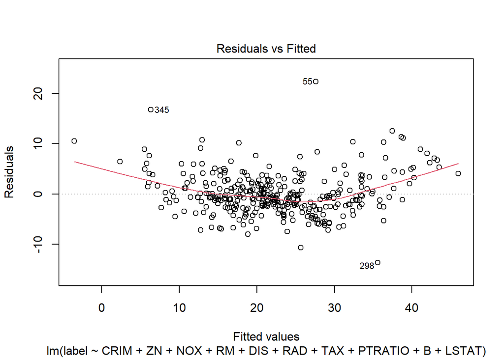

```r
plot(model2, which = 1)
```

잔차 0을 기준으로 적합값의 분포가 좌우 균등하면 잔차들은 등분산성 조건을 만족한다고 판단한다.

몇개의 이상치가 존재하지만, 큰 영향이 없으므로 이번 프로젝트에서는 그대로 진행하기로 한다.

### 정규성 검정, 다중 공선성 확인

```r
model2_residual <- residuals(model2) # 잔차
shapiro.test(model2_residual)
```

```
##
##  Shapiro-Wilk normality test
##
## data:  model2_residual
## W = 0.95011, p-value = 1.423e-09
```

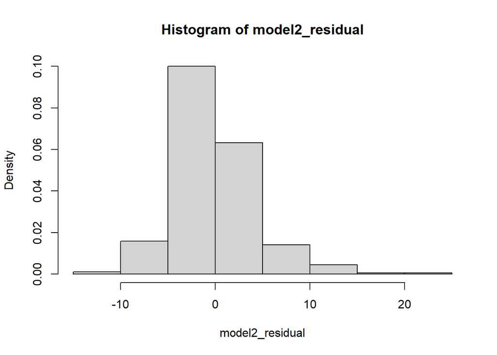

```r
hist(model2_residual, freq = F)
```

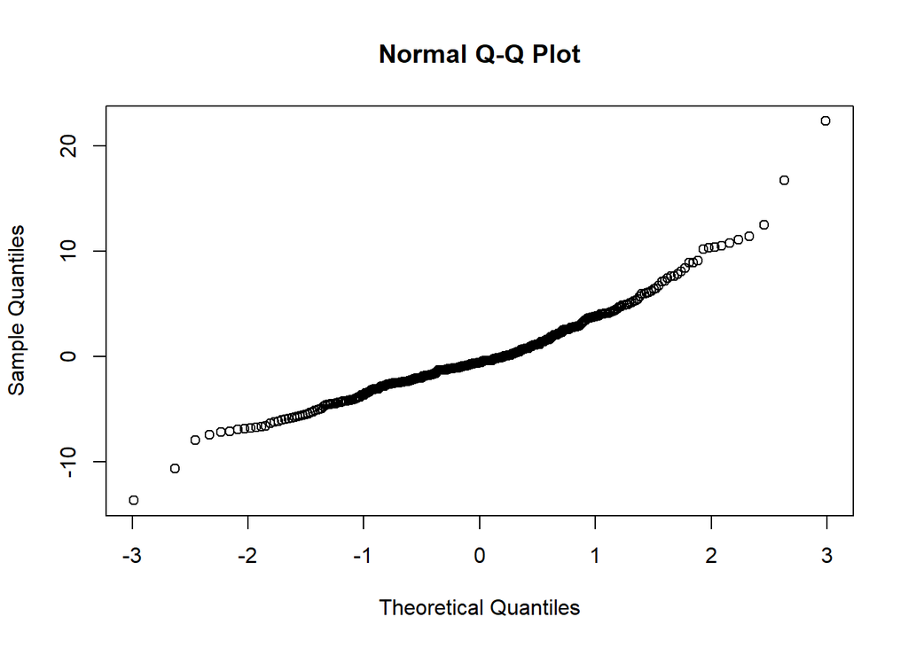

```r
qqnorm(model2_residual)
```

```r
vif(model2) > 10
```

```
##    CRIM      ZN     NOX      RM     DIS     RAD     TAX PTRATIO       B   LSTAT
##   FALSE   FALSE   FALSE   FALSE   FALSE   FALSE   FALSE   FALSE   FALSE   FALSE
```

shapiro의 p-value값은 0.05이하이므로 정규분포를 따르지 않는 데이터이다.

**다중 공선성 문제은 없다고 판단한다.**

### 모델 예측, 비교 시각화

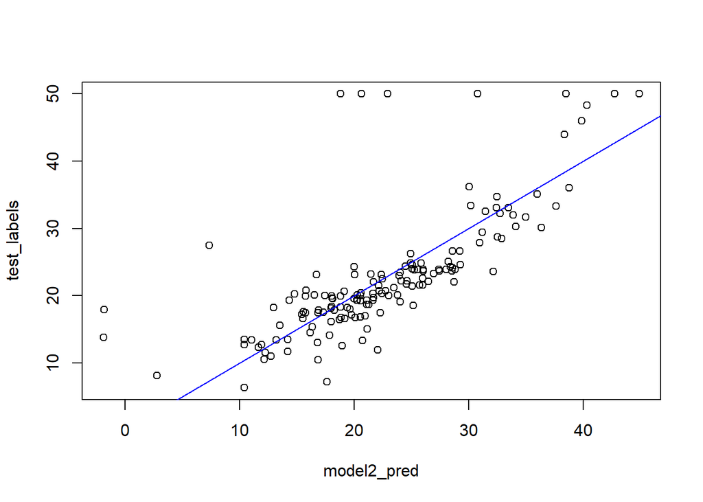

```r
model2_pred <- predict(model2, newdata = test_scale)
plot(model2_pred, test_labels)
abline(a=0,b=1,col="blue",lty=1)
```

R - Keras에 비해서 더 많은 이상치가 발견됐다.

### 모델 평가

```r
MAE <- mean(abs(model2_pred - test_labels))
```

```r
MAE
```

```r
cat('MAE: $',round(MAE * 1000))
```

```
## MAE: $ 3824
```

약 3824달러의 오차수준으로 예상하고 있다.

# 결론

`R keras`를 이용하기 위해서는 `Python keras`을 이용해야 했으나, 기본적인 성능은 크게 다르지 않았기 때문에 분석 요건에 따라 원하는 옵션과 기능이 있는 패키지를 선택하여 분석하는 능력이 중요하다 볼 수 있었다.

다중회귀분석의 성능은 Keras패키지가 내장함수보다 월등히 우수했고, 사용 언어에 따라서는 Python이 R보다 근소하게 좋은 결과를 보였다.

단, `set.seed()`설정에 따라 도출되는 결과값은 상이할 수 있으며, Python과 R 중에 본인이 선호하는 언어를 사용하는 것을 추천하는 바이다.

# 참조

[Boston Housing Datasets](https://ai-times.tistory.com/431)

[feature_spec()](https://tensorflow.rstudio.com/guide/tfdatasets/feature_spec)

[step_numeric_column()](https://www.rdocumentation.org/packages/tfdatasets/versions/2.2.0/topics/step_numeric_column)

[normalizer_fn](https://www.rdocumentation.org/packages/tfdatasets/versions/2.2.0/topics/scaler)

[layer_dense()](https://blog.daum.net/geoscience/1162)

[activation](https://keras.rstudio.com/reference/activation_relu.html)

[compile()](https://keras.rstudio.com/reference/compile.html)

[fit()](https://keras.rstudio.com/reference/fit.keras.engine.training.Model.html)